# QMSS 4063: Final Visualization Project, first draft

Hannah Fresques

April 28, 2015

For my final visualization project, I will be using D3 to create an interactive map of Delhi, on which to show demographic variables and energy usage data.

I am using data collected and processed by Sonia Lee and Eliot Cohen.

This document shows a rough first draft of my final project. I am using R for now, to get a sense of the data. I plan to build up the interactive visualizations in D3 after May 1.

I could use help identifying a target conference. I have searched online for conferences related to energy use and/or international development. I identified several conferences of interest, but none had available information on submitting research, either because the conference is held in the spring (thus Spring 2016 conference information is not yet available), or because the conference appears to not accept proposals.

# R environment setup

A note on file locations: All files are from the shared GoogleDrive for this project. I have downloaded the files I need locally, and document along the way the original GoogleDrive folder location of these files. For my final web visualization, I will include necessary files in the project repository.

```r
#library(rgdal)
#library(rgeos)
library(RColorBrewer)
library(sp)
library(maps)
library(maptools)
library(reshape)
library(deldir)
library(rCharts)
library(rMaps)
library(xlsx)
library(ggplot2)
library(plyr)
setwd("~/ColumbiaDrive/2015_Spring/QMSS_G4063/delhi-project/")
```

# Census data

```r
# Shared-delhi-project/Delhi Data 2008 - 2013/Census India 2011 data/subdivision_population_level.xlsx
cenc <- read.xlsx("census-data/subdivision_population_level.xlsx", sheetIndex=1)
cenc <- cenc[2:nrow(cenc),]
```

# Energy use file

Summary of energy usage by subdistrict is taken from Sonia Lee’s 2/3/2015 thesis draft. Is there a better file I should use?

```r
energy <- read.xlsx("usage-data/electricity-usage-by-subdistrict.xlsx", sheetIndex=1)
colnames(energy)[2] <- "subdistrict"

fullData <- merge(cenc, energy, by="subdistrict")
```

# File to link between census data and shape file subdistricts

```r
# file to link between subdiv numeric IDs on the shp file and actual subdiv names.
# Shared-delhi-project/Delhi Data 2008 - 2013/Delhi .shp files/subdivIDs.csv
subdivKey <- read.csv("map-data/subdivIDs.csv")
colnames(subdivKey)[1:2] <- c("subdistrictID", "subdistrict")
subdivKey$subdistrict <- as.character(subdivKey$subdistrict)
subdivKey$subdistrictID <- as.character(subdivKey$subdistrictID)
```

# Delhi shape file

Load file, and set-up link with census data

```r
# Shared-delhi-project/Delhi Data 2008 - 2013/Delhi .shp files/Consumption Choropleth/subdistricts
# note: .shp, .shx, and .dbf all needed
delhi <- readShapePoly("map-data/subdistricts")

delhi <- fortify(delhi, id = "subdistrict") # convert to R dataframe for mapping
# Change the IDs in the shape file to subdistrict name instead of numeric ID
# use subdivKey to do this
for (i in unique(subdivKey$subdistrictID) ) {
  delhi$id[which(delhi$id == i)] <- subdivKey$subdistrict[which(subdivKey$subdistrictID == i)]
}
# identify the center of each subdivision (used to add labels to the map)
distcenters <- ddply(delhi, .(id), summarize, clat = mean(lat), clong = mean(long))
```

# Plot the data

Growth rate over the past decade, plus alpha layer to represent energy usage. This would be layered over the growth rate plot.

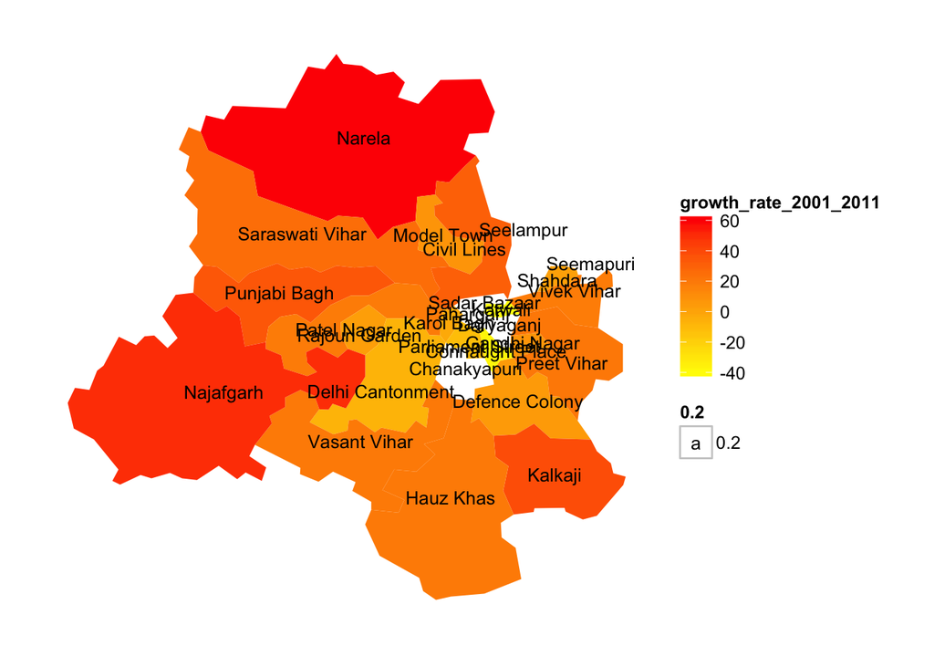

```r
emptyTheme <- theme(axis.line=element_blank(),axis.text.x=element_blank(),
                    axis.text.y=element_blank(),axis.ticks=element_blank(),
                    axis.title.x=element_blank(),
                    axis.title.y=element_blank(),
                    #legend.position="none",
                    panel.background=element_blank(),panel.border=element_blank(),panel.grid.major=element_blank(),
                    panel.grid.minor=element_blank(),plot.background=element_blank())

p1 <- ggplot() + geom_map(data = fullData, aes(map_id = subdistrict, fill = growth_rate_2001_2011), map = delhi) +
                    expand_limits(x = delhi$long, y = delhi$lat) +
                    theme_bw() +
                    scale_fill_gradient(low = "yellow", high = "red",
                                        #midpoint = median(fullData$growth_rate_2001_2011),
                                        guide = "colourbar",
                                        limits = c(min(fullData$growth_rate_2001_2011), max(fullData$growth_rate_2001_2011))) +
                    geom_text(data = distcenters, aes(x = clong, y = clat, label = id, size = 0.2))

p1 + emptyTheme
```

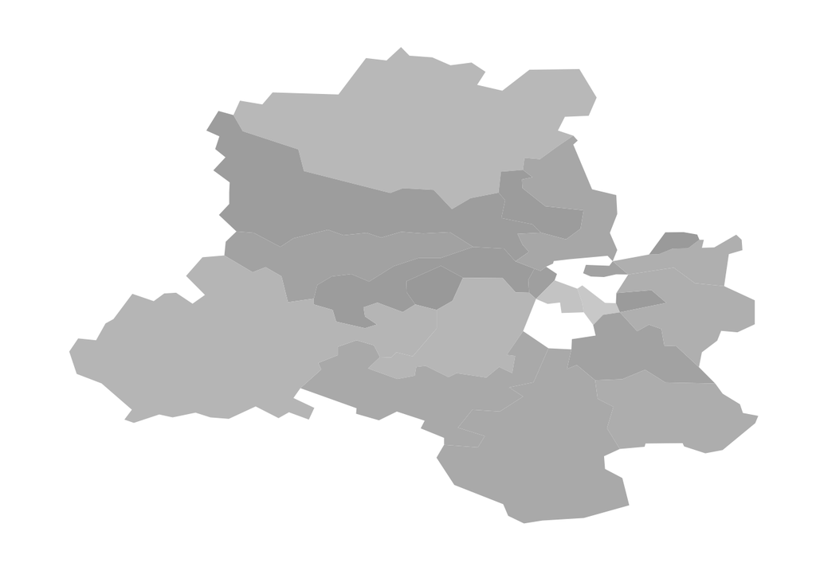

```r
p2 <- ggplot() + geom_map(data = fullData, aes(map_id = subdistrict, fill = Annual.per.capita.consumption..KWh.), map = delhi) +
                    expand_limits(x = delhi$long, y = delhi$lat) +
                    theme_bw() +
                    scale_fill_gradient(low = "dark grey", high = "light grey")
p2 + emptyTheme + theme(legend.position="none")
```

There’s clearly a lot that could be done to make this graph more informative and readable, but since my final product will be in D3, I’m not going to spend much time on the R aesthetics.

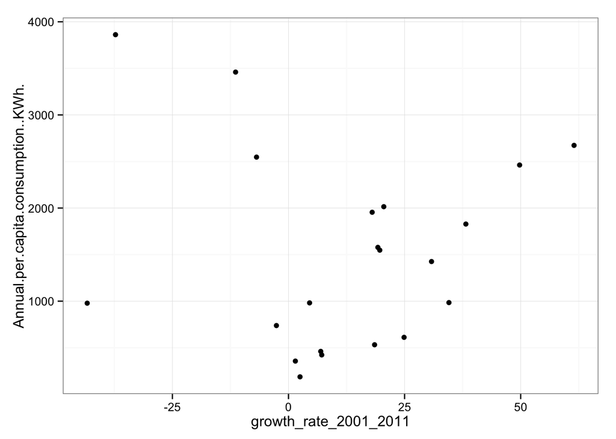

```r
p3 <- ggplot(data=fullData, aes(x=growth_rate_2001_2011, y=Annual.per.capita.consumption..KWh.)) +
      geom_point() +
      theme_bw()

p3
```

# Questions and next steps

The final product will be entirely web-based, and will include an interactive D3 map visualization. The map will be value-by-alpha where census variables are the values, and energy use is the alpha. The user will be able to choose which census variable to visualize (one at a time). The user will also be able to toggle on/off the alpha filter for energy use, and mouse-over to reveal data values and subdistrict name.

I will include a scatter plot, visualizing census variables against energy usage. (When a census variable is selected, the map and scatter plot will generate.)

I plan to use the census variables highlighted in Sonia’s thesis: housing conditions, population size, population growth rate, sex ratio in 2001 and 2011, percent child population, sex ratio of children in 2001 and 2011, literacy rate overall and by gender, labor force participation.

I am also interested to know if a measure of outages has been constructed from the raw data. If so, I’d like to include that measure as well.